# Next word prediction using N-grams - Text Data Analysis

Bharathwaj Sundaresan

3/14/2021

### Executive Summary

Around the world, people are spending an increasing amount of time on their mobile devices for email, social networking, banking and a whole range of other activities. But typing on mobile devices can be a serious pain. This project focuses on analyzing a large corpus of text documents to discover the structure in the data and how words are put together. This is a markdown report, showcasing the progress so far and some highlights on the next steps.

The data for this analysis is sourced from the internet, using web crawler to extract text data from various sources like twitter, news and blogs. all the text data are sourced in **English** language.

### Load and process data

Let us load the text data from the three sources and view its summary.

```r
set.seed(1220)

twitter <- file("data/Coursera-SwiftKey/final/en_US/en_US.twitter.txt", "r")
tweet<-readLines(twitter)

blogs <- file("data/Coursera-SwiftKey/final/en_US/en_US.blogs.txt", "r")
blog<-readLines(blogs)

news <- file("data/Coursera-SwiftKey/final/en_US/en_US.news.txt", "r")
new<-readLines(news)

#Close the connection
close(twitter)
close(blogs)
close(news)

#Get basic stats for each of the source
dtls<-data.frame(Source = c("Twitter", "Blogs", "News"),
              LineLength = c(length(tweet), length(blog), length(new)),
              Size = c(paste(round(as.numeric(object.size(tweet) / 1e+9), 2), "GB"),
                       paste(round(as.numeric(object.size(blog) / 1e+9), 2), "GB"),
                       paste(round(as.numeric(object.size(new) / 1e+9), 2), "GB"))
                 )
dtls
```

```
##    Source LineLength    Size
## 1 Twitter    2360148 0.33 GB
## 2   Blogs     899288 0.27 GB
## 3    News      77259 0.02 GB
```

We can see that the overall size of the corpus is around 0.62 GB. To perform the exploratory analysis, we can subset 20000 lines from the combined corpus. Let us clean the data by removing unwanted punctuation marks and multiple spaces found in the text. Also few bad words are observed in the raw data. Lets apply profanity filtering to remove these words from our training set.

```r
#Combine all data sources
dat = c(tweet, blog, new)

#Sample from the combined source
text = sample(dat, 20000)

#Remove unnecessary objects
rm("dat", "tweet", "blog", "new", "twitter", "blogs", "news")

#Remove any non-English characters from corpus
text<-iconv(text, from =  "latin1", to = "ASCII", sub = "")

#Tag all end of sentence punctuation to a string to be split later
text<-gsub("';|\\.|!|\\?'", "endofsentence", text, perl = TRUE)

#Clean multiple white spaces to single space
text <- trimws(gsub("\\s+", " ", text))

#Removes one letter words
text<-gsub("\\W*\\b\\w{1}\\b", " ", text, perl = TRUE)

#convert all text to lower case
text<-tolower(text)

#Remove Improper Words
text<-gsub("fuck|shit|piss off|dickhead|asshole|bitch|bastard|damn|cunt|bugger|motherfucker", "", text, perl = TRUE)

#Tag all end of sentence punctuation to a string to be split later
sentence<-data.frame(sentence = unlist(strsplit(text, "endofsentence", perl=T)))

#Remove records which are blank or single whitespace
sentence<-subset(sentence, sentence!="")
sentence<-subset(sentence, sentence!=" ")
```

Lets split the data to training and test sets.

```r
ind<-as.integer(nrow(sentence)*0.75)
train<-data.frame(sentence = sentence[1:ind,])
test<-data.frame(sentence = sentence[(ind+1):nrow(sentence),])
dim(train)
```

```
## [1] 29760     1
```

```r
dim(test)
```

```
## [1] 9921    1
```

### Tokenization

Now we have processed the corpus to sentences and split the data to training and test sets. Let us further split these sentences to words or combination of words as tokens.

```r
library(ggplot2)
library(caret)
library(dplyr)
library(quanteda)

train.tokens<-tokens(train$sentence,
                     what = "word",
                     remove_symbols = TRUE,
                     remove_numbers = TRUE,
                     remove_punct = TRUE,
                     remove_url = TRUE)
train.tokens<-tokens_tolower(train.tokens)
```

we have the `train.tokens` with words split from each sentence. Let us create Unigrams,BiGrams and Trigrams along with its corresponding document frequency matrix.

#### Unigram

```r
train.Ugram<-tokens_ngrams(train.tokens, n = 1)
dfm.Ugram<-dfm(train.Ugram, tolower = FALSE)
```

Top features from Unigram

```r
tstat_Ufreq<-textstat_frequency(dfm.Ugram)
df<-data.frame(tstat_Ufreq)
df1<- subset(df, frequency >3)

head(df1, 10)
```

```
##    feature frequency rank docfreq group
## 1      the     13315    1    8798   all
## 2       to      8573    2    6778   all
## 3      and      7032    3    5755   all
## 4       of      5959    4    4761   all
## 5       in      4617    5    4005   all
## 6      you      3818    6    3202   all
## 7       is      3701    7    3346   all
## 8       it      3608    8    3219   all
## 9     that      3499    9    3077   all
## 10     for      3451   10    3200   all
```

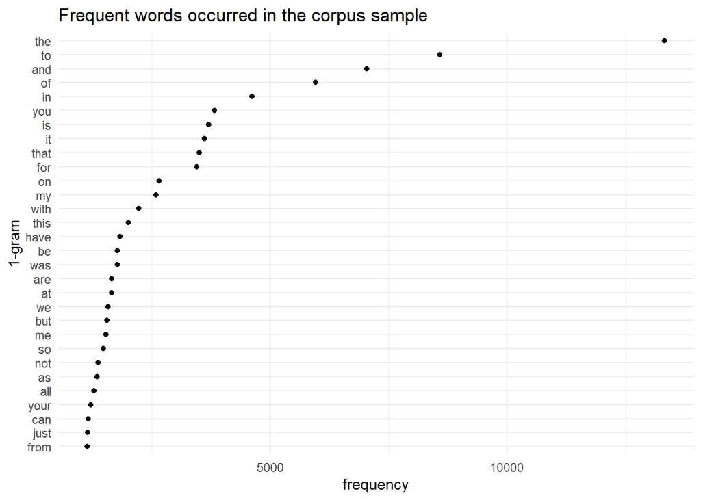

```r
dfm.Ugram %>%
  textstat_frequency(n = 30) %>%
  ggplot(aes(x = reorder(feature, frequency), y = frequency)) +
  geom_point() +
  coord_flip() +
  labs(title = "Frequent words occurred in the corpus sample", x = "1-gram")+
  theme_minimal()
```

#### BiGram

```r
train.Bgram<-tokens_ngrams(train.tokens, n = 2)
dfm.Bgram<-dfm(train.Bgram, tolower = FALSE)
```

Top features from BiGram

```r
tstat_Bfreq<-textstat_frequency(dfm.Bgram)
df<-data.frame(tstat_Bfreq)
df1<- subset(df, frequency >3)

head(df1, 10)
```

```
##     feature frequency rank docfreq group
## 1    of_the      1241    1    1143   all
## 2    in_the      1125    2    1072   all
## 3   for_the       613    3     596   all
## 4    on_the       589    4     574   all
## 5    to_the       583    5     567   all
## 6     to_be       507    6     495   all
## 7    at_the       386    7     378   all
## 8   and_the       326    8     316   all
## 9  with_the       296    9     294   all
## 10   it_was       288   10     282   all
```

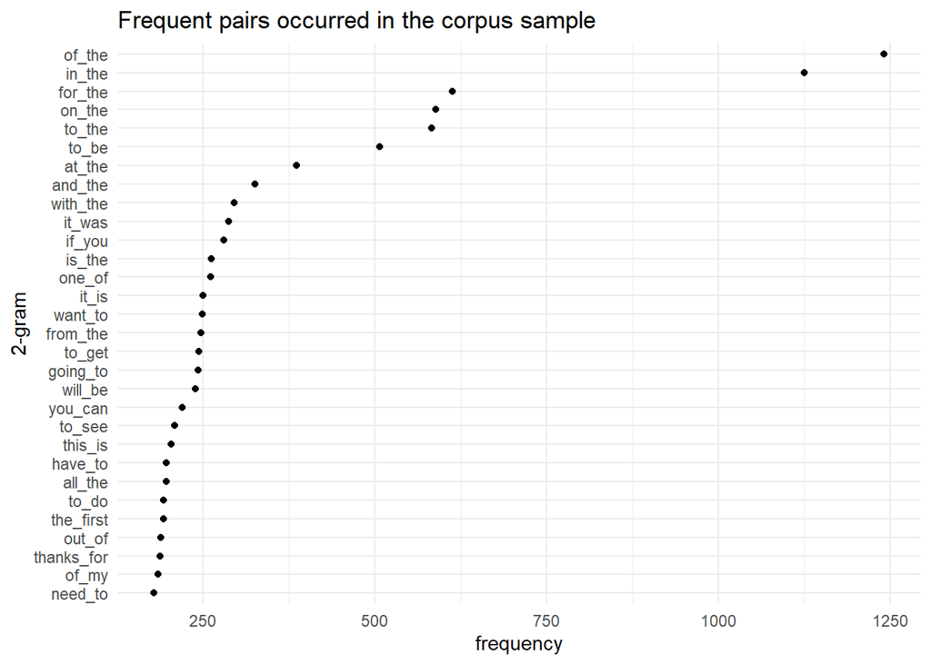

```r
dfm.Bgram %>%
  textstat_frequency(n = 30) %>%
  ggplot(aes(x = reorder(feature, frequency), y = frequency)) +
  geom_point() +
  coord_flip() +
  labs(title = "Frequent pairs occurred in the corpus sample", x = "2-gram")+
  theme_minimal()
```

#### TriGram

```r
train.Tgram<-tokens_ngrams(train.tokens, n = 3)
dfm.Tgram<-dfm(train.Tgram, tolower = FALSE)
```

Top features from TriGram

```r
tstat_Tfreq<-textstat_frequency(dfm.Tgram)
df<-data.frame(tstat_Tfreq)
df1<- subset(df, frequency >3)

head(df1, 10)
```

```
##               feature frequency rank docfreq group
## 1          one_of_the       124    1     120   all
## 2      thanks_for_the       102    2     102   all
## 3         going_to_be        58    3      57   all
## 4          out_of_the        53    4      52   all
## 5         the_rest_of        48    5      48   all
## 6         can_wait_to        48    5      48   all
## 7       thank_you_for        48    5      48   all
## 8         is_going_to        47    8      46   all
## 9  looking_forward_to        44    9      44   all
## 10         be_able_to        43   10      42   all
```

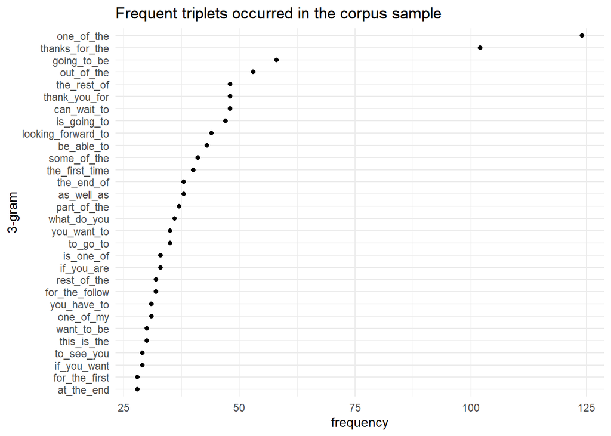

```r
dfm.Tgram %>%
  textstat_frequency(n = 30) %>%
  ggplot(aes(x = reorder(feature, frequency), y = frequency)) +
  geom_point() +
  coord_flip() +
  labs(title = "Frequent triplets occurred in the corpus sample", x = "3-gram")+
  theme_minimal()
```

### Next Steps

- Now we have the ngram models prepared and have an idea about the corpus. We can start implementing the word prediction model.
- Considering the Markov assumption, the probability of a next word depends only on the n-1 previous words, where n depends on the ngram input.
- Using the Good–Turing frequency estimation, we can smooth the proportion of columns in the ngrams.
- The Katz-Backoff model is considered for estimating the unobserved in unigrams but are prevalent in bigrams and trigrams.

Using the above methods, the prediction model will be incorporated in Shiny app. The user has a text interface to enter his text and receive predictions of the next word based on the words typed.